# PhySciM200 Assignment #1

Kevin Neal

April 8, 2015

```
## Package 'sm', version 2.2-5.4: type help(sm) for summary information
```

```
## [1] TRUE
```

## Part I: Further Reading

#### Eight ways of describing statistical methods:

1. Describe how you quantified your results and analyzed your data
2. State hypothesis you will test and the variables used to test the hypothesis
3. Consider assumptions made to allow data analysis
4. State significance level (i.e. which p-value) you chose to indicate statistical significance; justify value chosen; state if one- or two-sided test; and present actual p-value (with appropriate significant figures, e.g. with genomic analyses)
5. Do not claim groups are equivalent even if you fail to reject the null hypothesis; describe how sample size was determined in order to lessen impact of Type II error
6. A single global statistic is preferable to repeated pairwise testing; apply corrections for multiple testing and describe method used in correction
7. Choose methods that account for correlation between repeated (over time) or related/clustered observations
8. Give name, version, and source of software used to process data

## Part II: Data Analysis

```r
leptin <- read.csv(file="Leptin.csv", header=T) #must be in same folder as Rmd file... ugh
```

## Question A: Display leptin concentrations without regard to time

Histogram, box plot, and violin plot of 206 leptin concentrations:

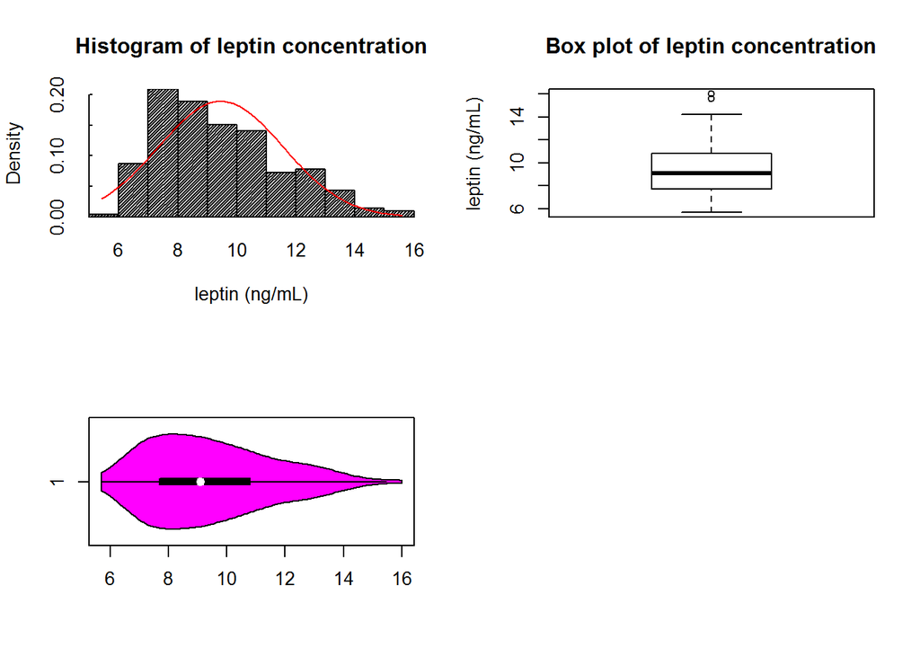

```r
# how do I make captions in markdown?
lept2 <- leptin[,2] #Just "leptin" column; could also just use leptin$Leptin throughout
par(mfrow=c(2,2))
hist(lept2, breaks=10, density=60, freq=F, main="Histogram of leptin concentration", xlab="leptin (ng/mL)", xaxs="i", yaxs="i", tck=0.02)
curve(dnorm(x, mean=mean(lept2), sd=sd(lept2)), add=T, col="red", lwd=1) # plots normal dist based on mean and stddev of your actual data
boxplot(lept2, main="Box plot of leptin concentration", ylab="leptin (ng/mL)", tck=0.02)
vioplot(lept2, horizontal=T) #not clear to me how to title this thing or apply any normal plot args...
par(mfrow=c(1,1))
```

## Question B: plot quantiles and determine if Gaussian

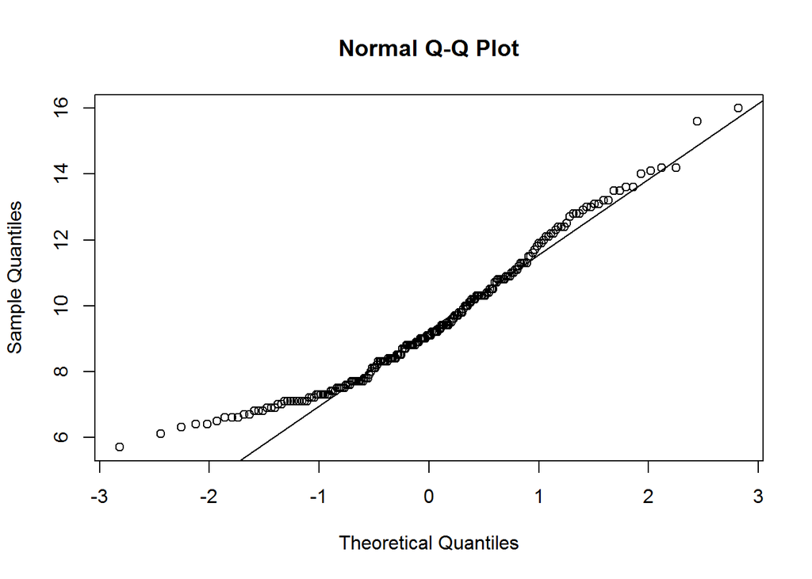

```r
qqnorm(lept2)
qqline(lept2)
```

The qqplot shows deviation from a normal/Gaussian distribution, therefore the median and 95% bootstrap confidence intervals are the better descriptors of central tendency and spread, rather than median and standard deviation.

```r
madam = function(data) {
  med = median(data)
  dev = median(abs(data-med))
  return(dev)
}
```

```r
bsLeptin <- bsMedian(leptin$Leptin)
```

```
## Median of 10000 bootstrapped leptin$Leptin medians, with 95% CI:
## 9.1 (8.8, 9.4)
```

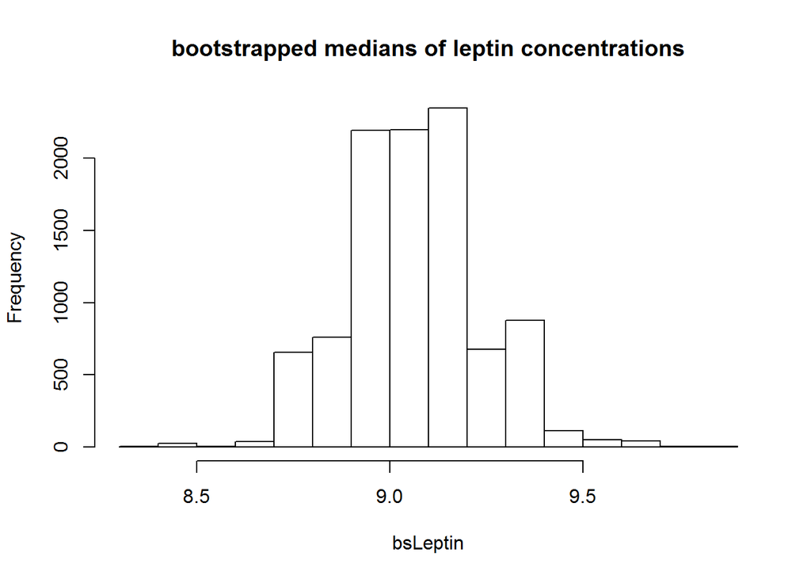

```r
hist(bsLeptin, main="bootstrapped medians of leptin concentrations")
```

```r
bsLeptinMadam <- bsMadam(leptin$Leptin)
```

```
## MADAM of 10000 bootstrapped leptin$Leptin medians, with 95% CI:
## 1.5 (1.3, 1.75)
```

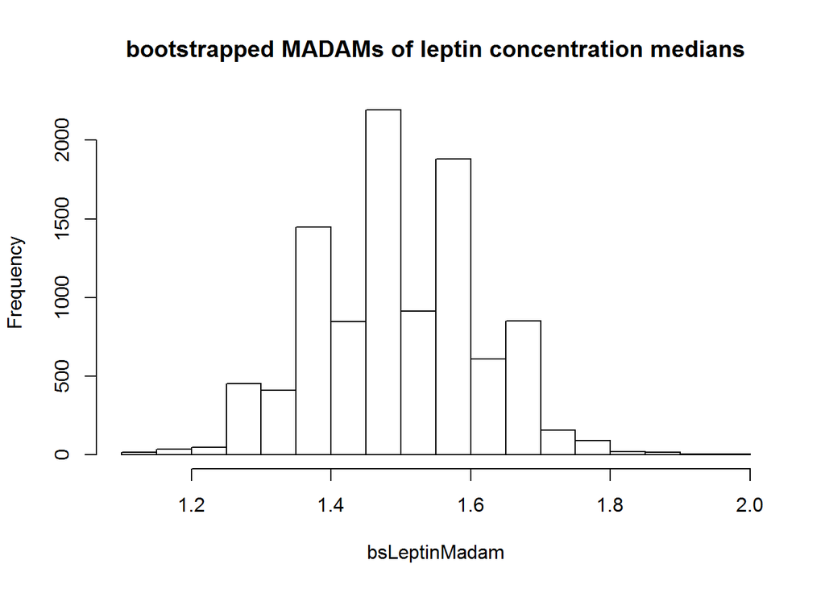

```r
hist(bsLeptinMadam, main="bootstrapped MADAMs of leptin concentration medians")
```

**Median of bootstrap-sampled medians and 95% CI: 9.1 (8.8, 9.4)**  
**Median of absolute deviation around the median (MADAM): 1.5 (1.30, 1.75)**

## Question C

```r
dayleptin <- leptin[which(leptin$Daylight==1),]
nightleptin <- leptin[which(leptin$Daylight==0),]

bsdayleptin <- bsMedian(dayleptin$Leptin)
```

```
## Median of 10000 bootstrapped dayleptin$Leptin medians, with 95% CI:
## 9.2 (8.7, 9.7)
```

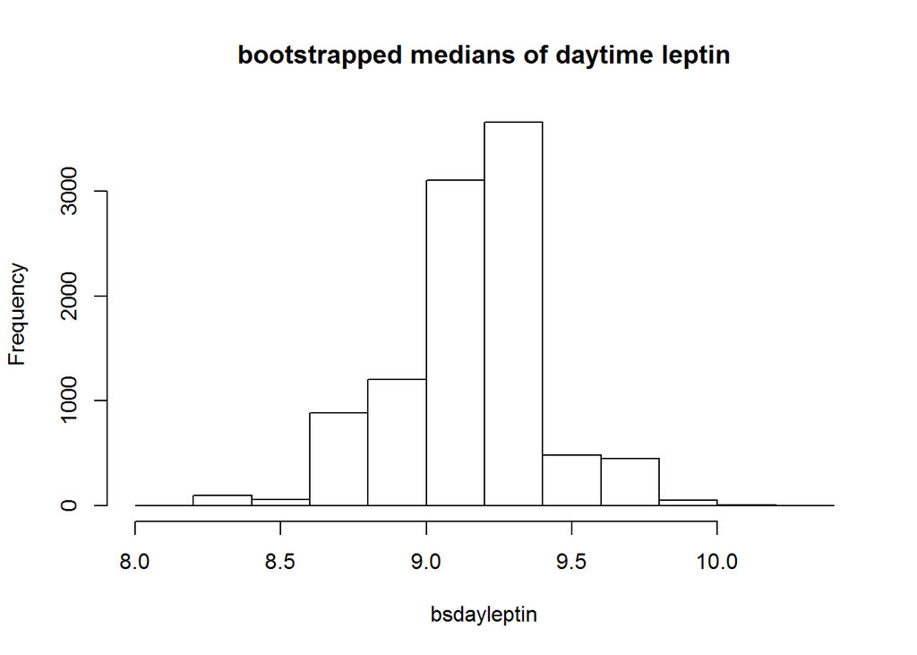

```r
hist(bsdayleptin, main="bootstrapped medians of daytime leptin")
```

```r
bsdayleptinMadam <- bsMadam(dayleptin$Leptin)
```

```
## MADAM of 10000 bootstrapped dayleptin$Leptin medians, with 95% CI:
## 1.7 (1.4, 1.9)
```

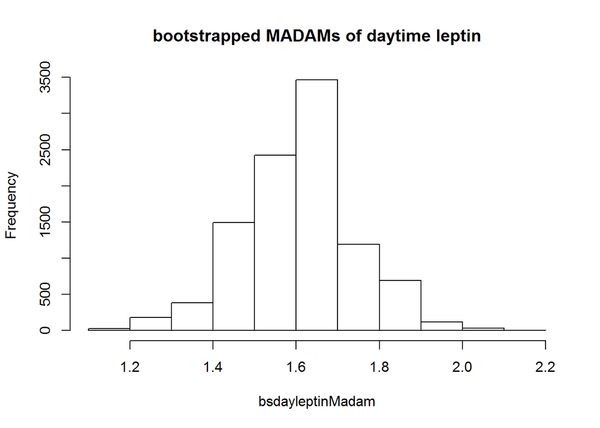

```r
hist(bsdayleptinMadam, main="bootstrapped MADAMs of daytime leptin")
```

Median of bootstrapped daytime leptin concentration: 9.2 (8.7, 9.7) MADAM of bootstrapped daytime leptin concentration: 1.7 (1.4, 1.9)

```r
bsnightleptin <- bsMedian(nightleptin$Leptin)
```

```
## Median of 10000 bootstrapped nightleptin$Leptin medians, with 95% CI:
## 9 (8.5, 9.5)
```

[figure not shown]

```r
hist(bsdayleptin, main="bootstrapped medians of nighttime leptin")
```

```r
bsnightleptinMadam <- bsMadam(nightleptin$Leptin)
```

```
## MADAM of 10000 bootstrapped nightleptin$Leptin medians, with 95% CI:
## 1.3 (0.8, 1.6)
```

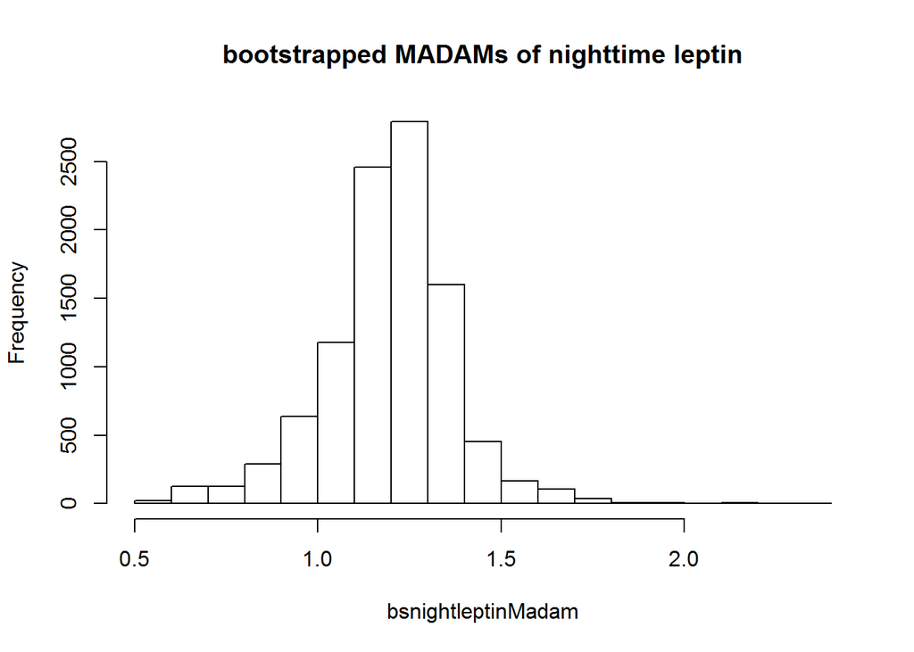

```r
hist(bsnightleptinMadam, main="bootstrapped MADAMs of nighttime leptin")
```

Median of 10000 sampled medians of daytime leptin concentration: 9.2 (8.7, 9.7)  
MADAM of daytime leptin concentration: 1.7 (1.4, 1.9)  
Median of 10000 sampled medians of nighttime leptin: 9.0 (8.5, 9.5)  
MADAM of nighttime leptin concentration: 1.3 (0.8, 1.6)

for the time-series in questions c and d, create a time-series vector for the data. Measurements were taken every 7 minutes, so use an interval of 420 seconds over 24 hours:

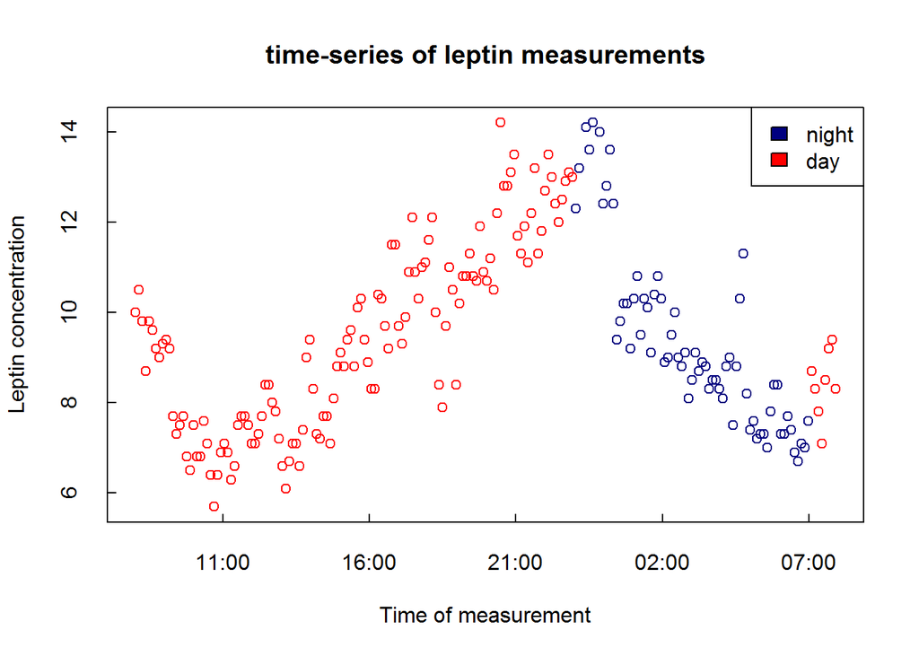

```r
leptin.ts <- seq(as.POSIXct("2013-10-10 08:00:00"), as.POSIXct("2013-10-11 08:00:00"), by=7*60)
# add to leptin object as fourth column named "Date"
leptin[,4] <- leptin.ts
colnames(leptin)[4] <- "Date"

# re-split into day and night but now with "Date" column
dayleptin <- leptin[which(leptin$Daylight==1),]
nightleptin <- leptin[which(leptin$Daylight==0),]

plot(dayleptin$Date, dayleptin$Leptin, col="red", main="time-series of leptin measurements", ylab="Leptin concentration", xlab="Time of measurement", tck=0.02)
points(nightleptin$Date, nightleptin$Leptin, col="navy")
legend("topright", legend=c("night", "day"), fill=c("navy", "red"))
```

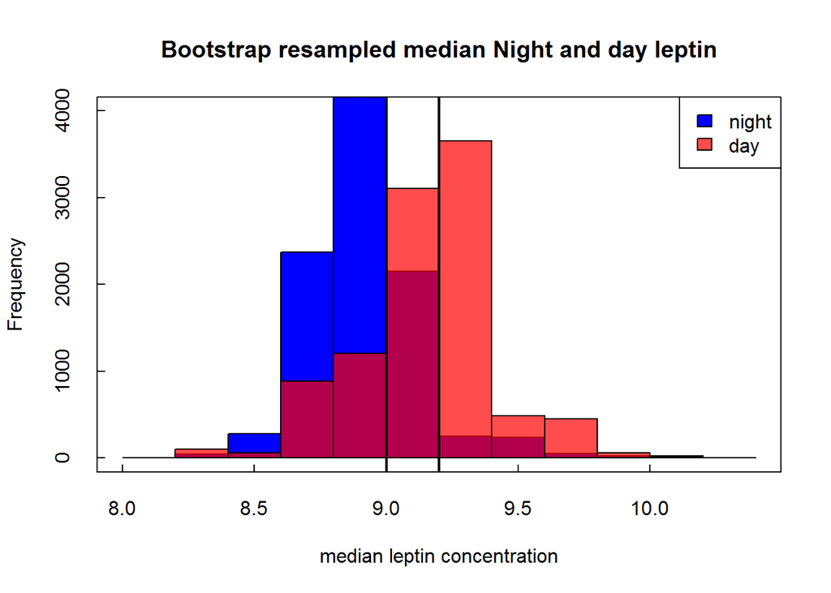

```r
hist(bsnightleptin, col=rgb(0,0,1,1), xlab="median leptin concentration", main="Bootstrap resampled median Night and day leptin", tck=0.02, ylim=c(0,4000))
hist(bsdayleptin, col=rgb(1, 0, 0, 0.7), add=T)
legend("topright", legend=c("night", "day"), fill=c("blue", rgb(1, 0, 0, 0.7)))
abline(v=median(bsnightleptin), lwd=2)
abline(v=median(bsdayleptin), lwd=2)
box()
```

## Question D

peak to peak and moving average:

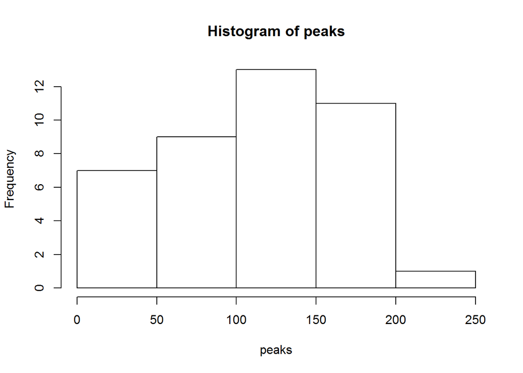

```r
datlen <- length(leptin$Leptin)
peaks <- rep(NA, datlen)
for (i in 2:(datlen - 1)) {
  isPeak <- leptin$Leptin[i-1] < leptin$Leptin[i] & leptin$Leptin[i] > leptin$Leptin[i+1]
  if (isPeak) # = TRUE is implicit here
    peaks[i] <- i
}
peaks <- peaks[!is.na(peaks)] # remove unused placeholders
hist(peaks) # ? Honestly not sure what to do with these peaks now...
```

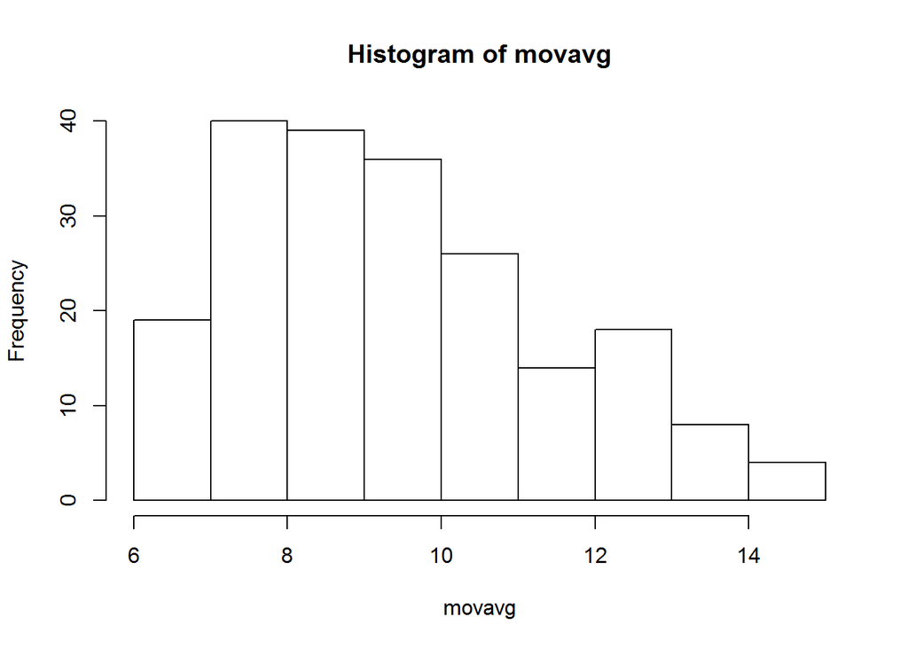

```r
# moving average: take avg of 3 points
movavg <- rep(NA, datlen)
for (p in 2:(datlen-1)) {
  movavg[p] <- mean( leptin$Leptin[ seq(from = p-1, to = p+1, by = 1)])
}
movavg <- movavg[!is.na(movavg)] # remove NAs
# x vector must be same length as movavg when plotting ... do same operations for the date column?
hist(movavg)
```

```r
length(movavg) # length is 204
```

```
## [1] 204
```

```r
# Bootstrapping the moving average dataset
bsmedMavg <- bsMedian(movavg)
```

```
## Median of 10000 bootstrapped movavg medians, with 95% CI:
## 9.2 (8.8, 9.533333)
```

```r
bsmadamMavg <- bsMadam(movavg)
```

```
## MADAM of 10000 bootstrapped movavg medians, with 95% CI:
## 1.5 (1.216667, 1.733333)
```

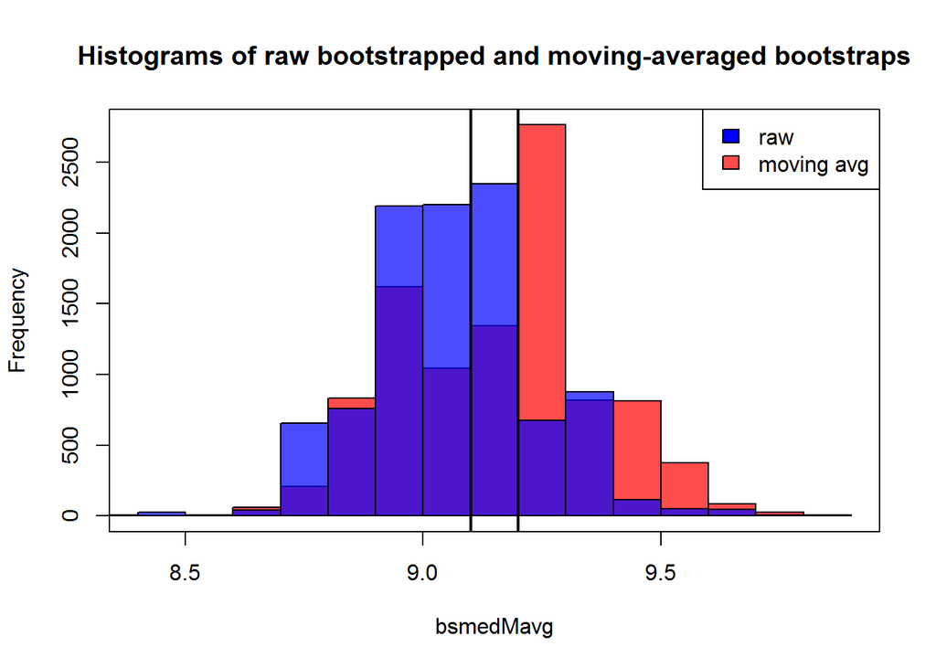

```r
# compare with raw dataset
hist(bsmedMavg, col=rgb(1,0,0,0.7), main="Histograms of raw bootstrapped and moving-averaged bootstraps")
hist(bsLeptin, col=rgb(0,0,1,0.7), add=T)
legend("topright", legend=c("raw", "moving avg"), fill=c("blue", rgb(1, 0, 0, 0.7)))
abline(v=median(bsLeptin), lwd=2)
abline(v=median(bsmedMavg), lwd=2)
box()
```